# The effect of dehorning and other potential factors influencing horn growth in game-ranched white rhinoceroses (Ceratotherium simum simum)

### Model selection

```
Call:
glm(formula = G_TOTAL ~ N_DEHORNINGS + CALC_AGE + GENDER, family = gaussian(link = "log"),
    data = df.cv.all)

Deviance Residuals:
    Min       1Q   Median       3Q      Max
-2.4434  -0.4522  -0.1100   0.2161  29.5909

Coefficients:
                Estimate Std. Error t value Pr(>|t|)
(Intercept)   -4.727e-01  8.178e-02  -5.779 9.79e-09 ***
N_DEHORNINGS2  1.232e+00  7.634e-02  16.140  < 2e-16 ***
N_DEHORNINGS3  1.440e+00  7.917e-02  18.191  < 2e-16 ***
CALC_AGE       9.878e-05  2.449e-05   4.034 5.86e-05 ***
GENDERM        3.094e-01  4.098e-02   7.550 9.23e-14 ***
---
Signif. codes:  0 ‘***’ 0.001 ‘**’ 0.01 ‘*’ 0.05 ‘.’ 0.1 ‘ ’ 1

(Dispersion parameter for gaussian family taken to be 2.140349)

    Null deviance: 4355.6  on 1085  degrees of freedom
Residual deviance: 2313.7  on 1081  degrees of freedom
AIC: 3915.3

Number of Fisher Scoring iterations: 6

Analysis of Deviance Table

Model: gaussian, link: log

Response: G_TOTAL

Terms added sequentially (first to last)

             Df Deviance Resid. Df Resid. Dev  Pr(>Chi)
NULL                          1085     4355.6
N_DEHORNINGS  2  1869.99      1083     2485.6 < 2.2e-16 ***
CALC_AGE      1    37.71      1082     2447.9 2.701e-05 ***
GENDER        1   134.20      1081     2313.7 2.408e-15 ***
---
Signif. codes:  0 ‘***’ 0.001 ‘**’ 0.01 ‘*’ 0.05 ‘.’ 0.1 ‘ ’ 1
```

### Interaction

```r
summary(glm8 <- glm(G_TOTAL~ N_DEHORNINGS*CALC_AGE + GENDER, df.cv.all, family = gaussian(link="log")))
```

```
Call:
glm(formula = G_TOTAL ~ N_DEHORNINGS * CALC_AGE + GENDER, family = gaussian(link = "log"),
    data = df.cv.all)

Deviance Residuals:
    Min       1Q   Median       3Q      Max
-2.6138  -0.4478  -0.1080   0.1855  29.6003

Coefficients:
                         Estimate Std. Error t value Pr(>|t|)
(Intercept)            -3.030e-01  1.354e-01  -2.238   0.0254 *
N_DEHORNINGS2           1.056e+00  1.467e-01   7.197 1.15e-12 ***
N_DEHORNINGS3           1.196e+00  1.748e-01   6.842 1.30e-11 ***
CALC_AGE               -2.770e-05  9.437e-05  -0.294   0.7691
GENDERM                 3.044e-01  4.122e-02   7.386 3.01e-13 ***
N_DEHORNINGS2:CALC_AGE  1.316e-04  9.909e-05   1.328   0.1846
N_DEHORNINGS3:CALC_AGE  1.598e-04  1.054e-04   1.515   0.1300
---
Signif. codes:  0 ‘***’ 0.001 ‘**’ 0.01 ‘*’ 0.05 ‘.’ 0.1 ‘ ’ 1

(Dispersion parameter for gaussian family taken to be 2.138469)

    Null deviance: 4355.6  on 1085  degrees of freedom
Residual deviance: 2307.4  on 1079  degrees of freedom
AIC: 3916.4

Number of Fisher Scoring iterations: 6
```

```r
anova(glm8, test = "Chisq")
```

```
Analysis of Deviance Table

Model: gaussian, link: log

Response: G_TOTAL

Terms added sequentially (first to last)

                      Df Deviance Resid. Df Resid. Dev  Pr(>Chi)
NULL                                   1085     4355.6
N_DEHORNINGS           2  1869.99      1083     2485.6 < 2.2e-16 ***
CALC_AGE               1    37.71      1082     2447.9 2.680e-05 ***
GENDER                 1   134.20      1081     2313.7 2.342e-15 ***
N_DEHORNINGS:CALC_AGE  2     6.30      1079     2307.4    0.2291
---
Signif. codes:  0 ‘***’ 0.001 ‘**’ 0.01 ‘*’ 0.05 ‘.’ 0.1 ‘ ’ 1
```

We conclude to drop the interaction in this model

### Final model least square means

```
$lsmeans
 N_DEHORNINGS response         SE df asymp.LCL asymp.UCL
 1            0.848225 0.06004746 NA 0.7383341 0.9744718
 2            2.907858 0.08378324 NA 2.7481968 3.0767956
 3            3.581065 0.12456964 NA 3.3450495 3.8337319

Results are averaged over the levels of: GENDER
Confidence level used: 0.95
Intervals are back-transformed from the log scale

$contrasts
 contrast response.ratio         SE df z.ratio p.value
 1 - 2         0.2917010 0.02226705 NA -16.140  <.0001
 1 - 3         0.2368639 0.01875336 NA -18.191  <.0001
 2 - 3         0.8120095 0.03225660 NA  -5.242  <.0001

Results are averaged over the levels of: GENDER
P value adjustment: tukey method for comparing a family of 3 estimates
Tests are performed on the log scale

 CALC_AGE response         SE df asymp.LCL asymp.UCL
 1552.464 2.067119 0.05959925 NA  1.953546  2.187295

Results are averaged over the levels of: N_DEHORNINGS, GENDER
Confidence level used: 0.95
Intervals are back-transformed from the log scale
$lsmeans
 GENDER response         SE df asymp.LCL asymp.UCL
 F      1.770864 0.07024483 NA  1.638403  1.914035
 M      2.412936 0.07353213 NA  2.273035  2.561447

Results are averaged over the levels of: N_DEHORNINGS
Confidence level used: 0.95
Intervals are back-transformed from the log scale

$contrasts
 contrast response.ratio         SE df z.ratio p.value
 F - M         0.7339045 0.03007342 NA   -7.55  <.0001

Results are averaged over the levels of: N_DEHORNINGS
Tests are performed on the log scale
```

## Hypothesis 3: Factors influencing the growth of the anterior horn weight in males and females

### Data preparation

```r
df.cv.all.f <- na.omit(df.cv[df.cv$G_AH_W < 100,
                             (names(df.cv) %in% c("CALC_AGE",
                                                  "DH_QUARTER",
                                                  "GENDER",
                                                  "G_AH_W",
                                                  "N_DEHORNINGS",
                                                  "B_QUARTER"))])
summary(df.cv.all.f)
```

```
 GENDER     CALC_AGE      DH_QUARTER B_QUARTER N_DEHORNINGS
 F:495   Min.   :  58.0   1:154      1:395     1:595
 M:588   1st Qu.: 922.5   2:294      2:312     2:314
         Median :1376.0   3:275      3:183     3:140
         Mean   :1553.6   4:360      4:193     4: 31
         3rd Qu.:1965.5                        5:  3
         Max.   :5909.0
     G_AH_W
 Min.   : 0.1148
 1st Qu.: 0.6573
 Median : 1.1052
 Mean   : 1.5912
 3rd Qu.: 2.2017
 Max.   :23.4286
```

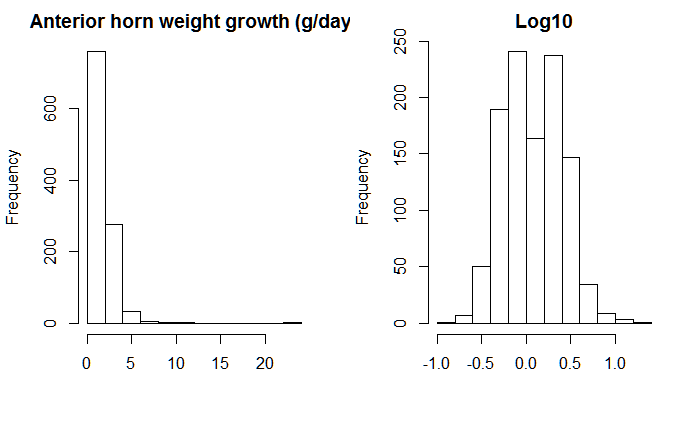

```r
df.cv.all.f[df.cv.all.f$N_DEHORNINGS == "4",]$N_DEHORNINGS <- "3"
df.cv.all.f[df.cv.all.f$N_DEHORNINGS == "5",]$N_DEHORNINGS <- "3"
#create histogram of the front horn weiht
op = par(mfrow=c(1, 2))
hist((df.cv.all.f$G_AH_W),
     main = "Anterior horn weight growth (g/day)",
     xlab ="")
hist(log10(df.cv.all.f$G_AH_W),
      main = "Log10",
     xlab ="")
```

### Model building

```
Call:
glm(formula = G_AH_W ~ 1, family = gaussian(link = "log"), data = df.cv.all.f)

Deviance Residuals:
    Min       1Q   Median       3Q      Max
-1.4765  -0.9339  -0.4860   0.6105  21.8373

Coefficients:
            Estimate Std. Error t value Pr(>|t|)
(Intercept)  0.46451    0.02777   16.73   <2e-16 ***
---
Signif. codes:  0 ‘***’ 0.001 ‘**’ 0.01 ‘*’ 0.05 ‘.’ 0.1 ‘ ’ 1

(Dispersion parameter for gaussian family taken to be 2.115181)

    Null deviance: 2288.6  on 1082  degrees of freedom
Residual deviance: 2288.6  on 1082  degrees of freedom
AIC: 3887.7

Number of Fisher Scoring iterations: 6


Call:
glm(formula = G_AH_W ~ N_DEHORNINGS, family = gaussian(link = "log"),
    data = df.cv.all.f)

Deviance Residuals:
    Min       1Q   Median       3Q      Max
-1.8056  -0.3797  -0.1146   0.1879  21.0315

Coefficients:
              Estimate Std. Error t value Pr(>|t|)
(Intercept)   -0.30239    0.06043  -5.004 6.55e-07 ***
N_DEHORNINGS2  1.17664    0.06565  17.923  < 2e-16 ***
N_DEHORNINGS3  1.41791    0.06622  21.413  < 2e-16 ***
---
Signif. codes:  0 ‘***’ 0.001 ‘**’ 0.01 ‘*’ 0.05 ‘.’ 0.1 ‘ ’ 1

(Dispersion parameter for gaussian family taken to be 1.186824)

```

[output cut: 90 more lines]

```

Coefficients:
            Estimate Std. Error t value Pr(>|t|)
(Intercept)  0.26916    0.04917   5.474 5.45e-08 ***
GENDERM      0.33458    0.05882   5.688 1.65e-08 ***
---
Signif. codes:  0 ‘***’ 0.001 ‘**’ 0.01 ‘*’ 0.05 ‘.’ 0.1 ‘ ’ 1

(Dispersion parameter for gaussian family taken to be 2.049889)

    Null deviance: 2288.6  on 1082  degrees of freedom
Residual deviance: 2215.9  on 1081  degrees of freedom
AIC: 3854.8

Number of Fisher Scoring iterations: 6
```

### Feature selection

```
Analysis of Deviance Table

Model 1: G_AH_W ~ 1
Model 2: G_AH_W ~ N_DEHORNINGS
Model 3: G_AH_W ~ CALC_AGE
Model 4: G_AH_W ~ DH_QUARTER
Model 5: G_AH_W ~ B_QUARTER
Model 6: G_AH_W ~ GENDER
  Resid. Df Resid. Dev Df Deviance  Pr(>Chi)
1      1082     2288.6
2      1080     1281.8  2  1006.85 < 2.2e-16 ***
3      1081     2117.2 -1  -835.39 < 2.2e-16 ***
4      1079     2286.8  2  -169.59
5      1079     2275.2  0    11.52
6      1081     2215.9 -2    59.31
---
Signif. codes:  0 ‘***’ 0.001 ‘**’ 0.01 ‘*’ 0.05 ‘.’ 0.1 ‘ ’ 1
Analysis of Deviance Table

Model 1: G_AH_W ~ 1
Model 2: G_AH_W ~ N_DEHORNINGS
  Resid. Df Resid. Dev Df Deviance  Pr(>Chi)
1      1082     2288.6
2      1080     1281.8  2   1006.9 < 2.2e-16 ***
---
Signif. codes:  0 ‘***’ 0.001 ‘**’ 0.01 ‘*’ 0.05 ‘.’ 0.1 ‘ ’ 1
Analysis of Deviance Table

Model 1: G_AH_W ~ 1
Model 2: G_AH_W ~ CALC_AGE
  Resid. Df Resid. Dev Df Deviance  Pr(>Chi)
1      1082     2288.6
2      1081     2117.2  1   171.46 < 2.2e-16 ***
---
Signif. codes:  0 ‘***’ 0.001 ‘**’ 0.01 ‘*’ 0.05 ‘.’ 0.1 ‘ ’ 1
Analysis of Deviance Table

Model 1: G_AH_W ~ 1
Model 2: G_AH_W ~ DH_QUARTER
  Resid. Df Resid. Dev Df Deviance Pr(>Chi)
1      1082     2288.6
2      1079     2286.8  3   1.8634   0.8304
Analysis of Deviance Table

Model 1: G_AH_W ~ 1
Model 2: G_AH_W ~ B_QUARTER
  Resid. Df Resid. Dev Df Deviance Pr(>Chi)
1      1082     2288.6
2      1079     2275.2  3   13.382  0.09593 .
---
Signif. codes:  0 ‘***’ 0.001 ‘**’ 0.01 ‘*’ 0.05 ‘.’ 0.1 ‘ ’ 1
Analysis of Deviance Table

Model 1: G_AH_W ~ 1
Model 2: G_AH_W ~ GENDER
  Resid. Df Resid. Dev Df Deviance Pr(>Chi)
1      1082     2288.6
2      1081     2215.9  1   72.694  2.6e-09 ***
---
Signif. codes:  0 ‘***’ 0.001 ‘**’ 0.01 ‘*’ 0.05 ‘.’ 0.1 ‘ ’ 1
```

### Model selection

```
Call:
glm(formula = G_AH_W ~ N_DEHORNINGS + CALC_AGE + GENDER, family = gaussian(link = "log"),
    data = df.cv.all.f)

Deviance Residuals:
    Min       1Q   Median       3Q      Max
-1.7836  -0.3680  -0.0907   0.1817  20.7565

Coefficients:
                Estimate Std. Error t value Pr(>|t|)
(Intercept)   -5.269e-01  6.992e-02  -7.535 1.03e-13 ***
N_DEHORNINGS2  1.146e+00  6.479e-02  17.692  < 2e-16 ***
N_DEHORNINGS3  1.330e+00  6.856e-02  19.403  < 2e-16 ***
CALC_AGE       6.165e-05  2.388e-05   2.582  0.00995 **
GENDERM        2.598e-01  3.749e-02   6.930 7.23e-12 ***
---
Signif. codes:  0 ‘***’ 0.001 ‘**’ 0.01 ‘*’ 0.05 ‘.’ 0.1 ‘ ’ 1

(Dispersion parameter for gaussian family taken to be 1.126531)

    Null deviance: 2288.6  on 1082  degrees of freedom
Residual deviance: 1214.4  on 1078  degrees of freedom
AIC: 3209.4

Number of Fisher Scoring iterations: 6

Analysis of Deviance Table

Model: gaussian, link: log

Response: G_AH_W

Terms added sequentially (first to last)

             Df Deviance Resid. Df Resid. Dev  Pr(>Chi)
NULL                          1082     2288.6
N_DEHORNINGS  2  1006.85      1080     1281.8 < 2.2e-16 ***
CALC_AGE      1     9.18      1079     1272.6  0.004312 **
GENDER        1    58.19      1078     1214.4 6.606e-13 ***
---
Signif. codes:  0 ‘***’ 0.001 ‘**’ 0.01 ‘*’ 0.05 ‘.’ 0.1 ‘ ’ 1
```

### Interaction

```r
summary(glm8 <- glm(G_AH_W~ N_DEHORNINGS*CALC_AGE +
                      GENDER*CALC_AGE, df.cv.all.f, family = gaussian(link="log")))
```

```
Call:
glm(formula = G_AH_W ~ N_DEHORNINGS * CALC_AGE + GENDER * CALC_AGE,
    family = gaussian(link = "log"), data = df.cv.all.f)

Deviance Residuals:
    Min       1Q   Median       3Q      Max
-2.0286  -0.3541  -0.0859   0.1601  20.7772

Coefficients:
                         Estimate Std. Error t value Pr(>|t|)
(Intercept)            -2.718e-01  1.278e-01  -2.127   0.0336 *
N_DEHORNINGS2           9.261e-01  1.281e-01   7.229 9.19e-13 ***
N_DEHORNINGS3           1.046e+00  1.601e-01   6.538 9.63e-11 ***
CALC_AGE               -1.231e-04  9.075e-05  -1.357   0.1751
GENDERM                 1.697e-01  9.764e-02   1.738   0.0825 .
N_DEHORNINGS2:CALC_AGE  1.691e-04  9.133e-05   1.852   0.0643 .
N_DEHORNINGS3:CALC_AGE  1.921e-04  9.877e-05   1.945   0.0520 .
CALC_AGE:GENDERM        4.389e-05  4.740e-05   0.926   0.3547
---
Signif. codes:  0 ‘***’ 0.001 ‘**’ 0.01 ‘*’ 0.05 ‘.’ 0.1 ‘ ’ 1

(Dispersion parameter for gaussian family taken to be 1.122788)

    Null deviance: 2288.6  on 1082  degrees of freedom
Residual deviance: 1207.0  on 1075  degrees of freedom
AIC: 3208.8

Number of Fisher Scoring iterations: 7
```

```r
anova(glm8, test = "Chisq")
```

```
Analysis of Deviance Table

Model: gaussian, link: log

Response: G_AH_W

Terms added sequentially (first to last)

                      Df Deviance Resid. Df Resid. Dev  Pr(>Chi)
NULL                                   1082     2288.6
N_DEHORNINGS           2  1006.85      1080     1281.8 < 2.2e-16 ***
CALC_AGE               1     9.18      1079     1272.6  0.004248 **
GENDER                 1    58.19      1078     1214.4 6.051e-13 ***
N_DEHORNINGS:CALC_AGE  2     6.44      1076     1208.0  0.056912 .
CALC_AGE:GENDER        1     0.97      1075     1207.0  0.352644
---
Signif. codes:  0 ‘***’ 0.001 ‘**’ 0.01 ‘*’ 0.05 ‘.’ 0.1 ‘ ’ 1
```

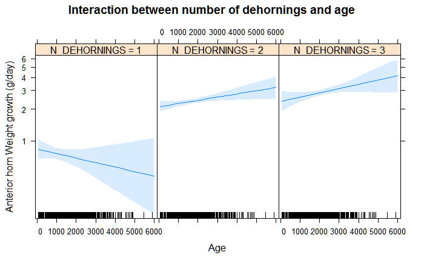

```r
plot(effect("N_DEHORNINGS:CALC_AGE",
            glm8,
            #xlevels=list(CALC_ARRIVAL=900:2000),
            multiline=TRUE),
     main= "Interaction between number of dehornings and age",
     ylab = "Anterior horn Weight growth (g/day)",
     xlab = "Age")
```

### Final model least square means

```
NOTE: Results may be misleading due to involvement in interactions
```

```
$lsmeans
 N_DEHORNINGS  response         SE df asymp.LCL asymp.UCL
 1            0.7087916 0.04899477 NA 0.6189846 0.8116286
 2            2.3272105 0.06244837 NA 2.2079769 2.4528829
 3            2.7203770 0.12365851 NA 2.4884937 2.9738677

Results are averaged over the levels of: GENDER
Confidence level used: 0.95
Intervals are back-transformed from the log scale

$contrasts
 contrast response.ratio         SE df z.ratio p.value
 1 - 2         0.3045670 0.02245851 NA -16.123  <.0001
 1 - 3         0.2605490 0.02143324 NA -16.350  <.0001
 2 - 3         0.8554735 0.04469707 NA  -2.988  0.0079

Results are averaged over the levels of: GENDER
P value adjustment: tukey method for comparing a family of 3 estimates
Tests are performed on the log scale
```

```
NOTE: Results may be misleading due to involvement in interactions
```

```
 CALC_AGE response         SE df asymp.LCL asymp.UCL
 1553.608 1.649407 0.04843013 NA  1.557165  1.747113

Results are averaged over the levels of: N_DEHORNINGS, GENDER
Confidence level used: 0.95
Intervals are back-transformed from the log scale
 N_DEHORNINGS CALC_AGE  response         SE df asymp.LCL asymp.UCL
 1            1553.608 0.7087916 0.04899477 NA 0.6189846 0.8116286
 2            1553.608 2.3272105 0.06244837 NA 2.2079769 2.4528829
 3            1553.608 2.7203770 0.12365851 NA 2.4884937 2.9738677

Results are averaged over the levels of: GENDER
Confidence level used: 0.95
Intervals are back-transformed from the log scale
```

```
NOTE: Results may be misleading due to involvement in interactions
```

```
$lsmeans
 GENDER response         SE df asymp.LCL asymp.UCL
 F      1.464446 0.05714883 NA  1.356613  1.580851
 M      1.857728 0.06014383 NA  1.743510  1.979428

Results are averaged over the levels of: N_DEHORNINGS
Confidence level used: 0.95
Intervals are back-transformed from the log scale

$contrasts
 contrast response.ratio         SE df z.ratio p.value
 F - M         0.7882999 0.03244028 NA   -5.78  <.0001

Results are averaged over the levels of: N_DEHORNINGS
Tests are performed on the log scale
```

## Hypothesis 4: Factors influencing the growth of the anterior horn length in males and females

### Data preparation

```r
df.cv.all.f.l <- na.omit(df.cv[df.cv$G_AH_L < 10,
                               (names(df.cv) %in% c("CALC_AGE",
                                                    "DH_QUARTER",
                                                    "GENDER",
                                                    "G_AH_L",
                                                    "N_DEHORNINGS",
                                                    "B_QUARTER"))])
summary(df.cv.all.f.l)
```

```
 GENDER     CALC_AGE      DH_QUARTER B_QUARTER N_DEHORNINGS
 F:494   Min.   :  58.0   1:152      1:394     1:590
 M:584   1st Qu.: 926.2   2:294      2:308     2:314
         Median :1381.0   3:273      3:183     3:140
         Mean   :1557.9   4:359      4:193     4: 31
         3rd Qu.:1966.8                        5:  3
         Max.   :5909.0
     G_AH_L
 Min.   :0.01447
 1st Qu.:0.18539
 Median :0.23081
 Mean   :0.22936
 3rd Qu.:0.26828
 Max.   :2.71429
```

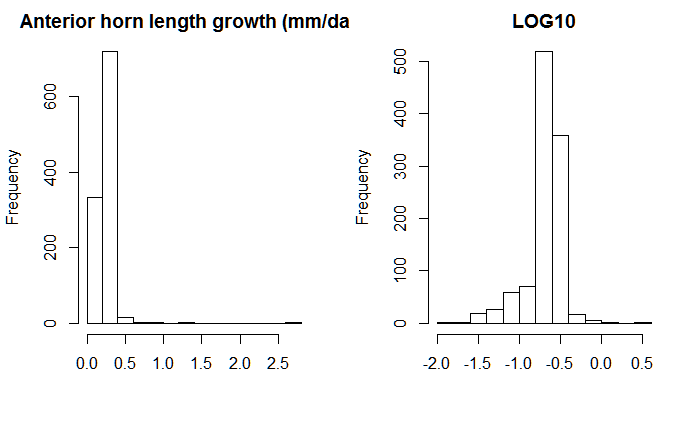

```r
df.cv.all.f.l[df.cv.all.f.l$N_DEHORNINGS == "4",]$N_DEHORNINGS <- "3"
df.cv.all.f.l[df.cv.all.f.l$N_DEHORNINGS == "5",]$N_DEHORNINGS <- "3"
op = par(mfrow=c(1, 2))
hist(df.cv.all.f.l$G_AH_L,
     main = "Anterior horn length growth (mm/day)",
     xlab ="")
hist(log10(df.cv.all.f.l$G_AH_L),
     main = "LOG10",
     xlab ="")
```

### Model building

```
Call:
glm(formula = G_AH_L ~ 1, family = gaussian(link = "log"), data = df.cv.all.f.l)

Deviance Residuals:
     Min        1Q    Median        3Q       Max
-0.21489  -0.04397   0.00145   0.03892   2.48493

Coefficients:
            Estimate Std. Error t value Pr(>|t|)
(Intercept) -1.47247    0.01617  -91.06   <2e-16 ***
---
Signif. codes:  0 ‘***’ 0.001 ‘**’ 0.01 ‘*’ 0.05 ‘.’ 0.1 ‘ ’ 1

(Dispersion parameter for gaussian family taken to be 0.01482908)

    Null deviance: 15.971  on 1077  degrees of freedom
Residual deviance: 15.971  on 1077  degrees of freedom
AIC: -1477.4

Number of Fisher Scoring iterations: 5


Call:
glm(formula = G_AH_L ~ N_DEHORNINGS, family = gaussian(link = "log"),
    data = df.cv.all.f.l)

Deviance Residuals:
     Min        1Q    Median        3Q       Max
-0.17756  -0.04458  -0.00398   0.03403   2.43691

Coefficients:
              Estimate Std. Error t value Pr(>|t|)
(Intercept)   -1.65007    0.02459 -67.092  < 2e-16 ***
N_DEHORNINGS2  0.36770    0.03391  10.845  < 2e-16 ***
N_DEHORNINGS3  0.33793    0.04060   8.324 2.56e-16 ***
---
Signif. codes:  0 ‘***’ 0.001 ‘**’ 0.01 ‘*’ 0.05 ‘.’ 0.1 ‘ ’ 1

(Dispersion parameter for gaussian family taken to be 0.01316085)

```

[output cut: 90 more lines]

```

Coefficients:
            Estimate Std. Error t value Pr(>|t|)
(Intercept) -1.50506    0.02465 -61.050   <2e-16 ***
GENDERM      0.05934    0.03262   1.819   0.0692 .
---
Signif. codes:  0 ‘***’ 0.001 ‘**’ 0.01 ‘*’ 0.05 ‘.’ 0.1 ‘ ’ 1

(Dispersion parameter for gaussian family taken to be 0.01479734)

    Null deviance: 15.971  on 1077  degrees of freedom
Residual deviance: 15.921  on 1076  degrees of freedom
AIC: -1478.8

Number of Fisher Scoring iterations: 5
```

### Model selection

```
Analysis of Deviance Table

Model 1: G_AH_L ~ 1
Model 2: G_AH_L ~ N_DEHORNINGS
Model 3: G_AH_L ~ CALC_AGE
Model 4: G_AH_L ~ DH_QUARTER
Model 5: G_AH_L ~ B_QUARTER
Model 6: G_AH_L ~ GENDER
  Resid. Df Resid. Dev Df Deviance  Pr(>Chi)
1      1077     15.971
2      1075     14.148  2  1.82272 < 2.2e-16 ***
3      1076     15.231 -1 -1.08274 < 2.2e-16 ***
4      1074     15.917  2 -0.68628
5      1074     15.961  0 -0.04377
6      1076     15.921 -2  0.03937
---
Signif. codes:  0 ‘***’ 0.001 ‘**’ 0.01 ‘*’ 0.05 ‘.’ 0.1 ‘ ’ 1
Analysis of Deviance Table

Model 1: G_AH_L ~ 1
Model 2: G_AH_L ~ N_DEHORNINGS
  Resid. Df Resid. Dev Df Deviance  Pr(>Chi)
1      1077     15.971
2      1075     14.148  2   1.8227 < 2.2e-16 ***
---
Signif. codes:  0 ‘***’ 0.001 ‘**’ 0.01 ‘*’ 0.05 ‘.’ 0.1 ‘ ’ 1
Analysis of Deviance Table

Model 1: G_AH_L ~ 1
Model 2: G_AH_L ~ CALC_AGE
  Resid. Df Resid. Dev Df Deviance  Pr(>Chi)
1      1077     15.971
2      1076     15.231  1  0.73998 4.819e-13 ***
---
Signif. codes:  0 ‘***’ 0.001 ‘**’ 0.01 ‘*’ 0.05 ‘.’ 0.1 ‘ ’ 1
Analysis of Deviance Table

Model 1: G_AH_L ~ 1
Model 2: G_AH_L ~ DH_QUARTER
  Resid. Df Resid. Dev Df Deviance Pr(>Chi)
1      1077     15.971
2      1074     15.917  3 0.053701   0.3051
Analysis of Deviance Table

Model 1: G_AH_L ~ 1
Model 2: G_AH_L ~ B_QUARTER
  Resid. Df Resid. Dev Df  Deviance Pr(>Chi)
1      1077     15.971
2      1074     15.961  3 0.0099274   0.8807
Analysis of Deviance Table

Model 1: G_AH_L ~ 1
Model 2: G_AH_L ~ GENDER
  Resid. Df Resid. Dev Df Deviance Pr(>Chi)
1      1077     15.971
2      1076     15.921  1 0.049302  0.06795 .
---
Signif. codes:  0 ‘***’ 0.001 ‘**’ 0.01 ‘*’ 0.05 ‘.’ 0.1 ‘ ’ 1
```

### Final model selection

```
Call:
glm(formula = G_AH_L ~ N_DEHORNINGS + CALC_AGE + GENDER, family = gaussian(link = "log"),
    data = df.cv.all.f.l)

Deviance Residuals:
     Min        1Q    Median        3Q       Max
-0.17248  -0.04321  -0.01186   0.02387   2.43545

Coefficients:
                Estimate Std. Error t value Pr(>|t|)
(Intercept)   -1.217e+00  3.726e-02  -32.66   <2e-16 ***
N_DEHORNINGS2  5.326e-01  3.442e-02   15.47   <2e-16 ***
N_DEHORNINGS3  7.036e-01  4.976e-02   14.14   <2e-16 ***
CALC_AGE      -3.838e-04  2.975e-05  -12.90   <2e-16 ***
GENDERM        5.222e-02  2.692e-02    1.94   0.0527 .
---
Signif. codes:  0 ‘***’ 0.001 ‘**’ 0.01 ‘*’ 0.05 ‘.’ 0.1 ‘ ’ 1

(Dispersion parameter for gaussian family taken to be 0.01080129)

    Null deviance: 15.971  on 1077  degrees of freedom
Residual deviance: 11.589  on 1073  degrees of freedom
AIC: -1815.1

Number of Fisher Scoring iterations: 7

Analysis of Deviance Table

Model: gaussian, link: log

Response: G_AH_L

Terms added sequentially (first to last)

             Df Deviance Resid. Df Resid. Dev Pr(>Chi)
NULL                          1077     15.971
N_DEHORNINGS  2  1.82272      1075     14.148  < 2e-16 ***
CALC_AGE      1  2.51740      1074     11.630  < 2e-16 ***
GENDER        1  0.04102      1073     11.589  0.05131 .
---
Signif. codes:  0 ‘***’ 0.001 ‘**’ 0.01 ‘*’ 0.05 ‘.’ 0.1 ‘ ’ 1
```

### Interaction

```r
summary(glm8 <- glm(G_AH_L~ N_DEHORNINGS*CALC_AGE +
                      GENDER, df.cv.all.f.l, family = gaussian(link="log")))
```

```
Call:
glm(formula = G_AH_L ~ N_DEHORNINGS * CALC_AGE + GENDER, family = gaussian(link = "log"),
    data = df.cv.all.f.l)

Deviance Residuals:
     Min        1Q    Median        3Q       Max
-0.18121  -0.03726  -0.00993   0.01848   2.43027

Coefficients:
                         Estimate Std. Error t value Pr(>|t|)
(Intercept)            -9.875e-01  5.089e-02 -19.405  < 2e-16 ***
N_DEHORNINGS2           4.118e-02  8.136e-02   0.506    0.613
N_DEHORNINGS3          -3.404e-03  1.429e-01  -0.024    0.981
CALC_AGE               -6.250e-04  5.204e-05 -12.010  < 2e-16 ***
GENDERM                 3.807e-02  2.632e-02   1.446    0.148
N_DEHORNINGS2:CALC_AGE  4.165e-04  6.477e-05   6.431 1.91e-10 ***
N_DEHORNINGS3:CALC_AGE  4.708e-04  7.946e-05   5.925 4.21e-09 ***
---
Signif. codes:  0 ‘***’ 0.001 ‘**’ 0.01 ‘*’ 0.05 ‘.’ 0.1 ‘ ’ 1

(Dispersion parameter for gaussian family taken to be 0.01032666)

    Null deviance: 15.971  on 1077  degrees of freedom
Residual deviance: 11.060  on 1071  degrees of freedom
AIC: -1861.5

Number of Fisher Scoring iterations: 6
```

```r
anova(glm8, test = "Chisq")
```

```
Analysis of Deviance Table

Model: gaussian, link: log

Response: G_AH_L

Terms added sequentially (first to last)

                      Df Deviance Resid. Df Resid. Dev  Pr(>Chi)
NULL                                   1077     15.971
N_DEHORNINGS           2  1.82272      1075     14.148 < 2.2e-16 ***
CALC_AGE               1  2.51740      1074     11.630 < 2.2e-16 ***
GENDER                 1  0.04102      1073     11.589   0.04625 *
N_DEHORNINGS:CALC_AGE  2  0.52973      1071     11.060 7.259e-12 ***
---
Signif. codes:  0 ‘***’ 0.001 ‘**’ 0.01 ‘*’ 0.05 ‘.’ 0.1 ‘ ’ 1
```

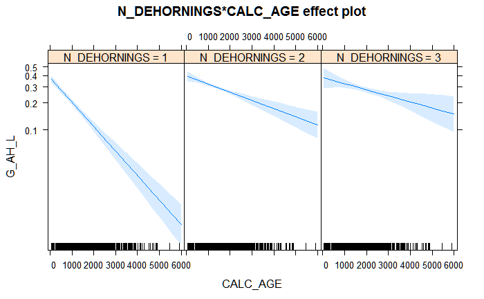

```r
plot(effect("N_DEHORNINGS:CALC_AGE",
            glm8,
            multiline=TRUE))
```

### Final model least square means

```
NOTE: Results may be misleading due to involvement in interactions
```

```
$lsmeans
 N_DEHORNINGS  response          SE df asymp.LCL asymp.UCL
 1            0.1433888 0.006034328 NA 0.1320364 0.1557173
 2            0.2859036 0.005889743 NA 0.2745898 0.2976835
 3            0.2975482 0.014046665 NA 0.2712525 0.3263931

Results are averaged over the levels of: GENDER
Confidence level used: 0.95
Intervals are back-transformed from the log scale

$contrasts
 contrast response.ratio         SE df z.ratio p.value
 1 - 2         0.5015286 0.02348277 NA -14.739  <.0001
 1 - 3         0.4819011 0.03048490 NA -11.540  <.0001
 2 - 3         0.9608646 0.04950446 NA  -0.775  0.7185

Results are averaged over the levels of: GENDER
P value adjustment: tukey method for comparing a family of 3 estimates
Tests are performed on the log scale
```

```
NOTE: Results may be misleading due to involvement in interactions
```

```
 CALC_AGE  response         SE df asymp.LCL asymp.UCL
 1557.904 0.2301958 0.00510341 NA 0.2204075 0.2404188

Results are averaged over the levels of: N_DEHORNINGS, GENDER
Confidence level used: 0.95
Intervals are back-transformed from the log scale
 N_DEHORNINGS CALC_AGE  response          SE df asymp.LCL asymp.UCL
 1            1557.904 0.1433888 0.006034328 NA 0.1320364 0.1557173
 2            1557.904 0.2859036 0.005889743 NA 0.2745898 0.2976835
 3            1557.904 0.2975482 0.014046665 NA 0.2712525 0.3263931

Results are averaged over the levels of: GENDER
Confidence level used: 0.95
Intervals are back-transformed from the log scale
$lsmeans
 GENDER  response          SE df asymp.LCL asymp.UCL
 F      0.2258551 0.005893147 NA 0.2145952 0.2377059
 M      0.2346199 0.005975375 NA 0.2231959 0.2466286

Results are averaged over the levels of: N_DEHORNINGS
Confidence level used: 0.95
Intervals are back-transformed from the log scale

$contrasts
 contrast response.ratio         SE df z.ratio p.value
 F - M         0.9626428 0.02533976 NA  -1.446  0.1481

Results are averaged over the levels of: N_DEHORNINGS
Tests are performed on the log scale
```

## Hypothesis 5: Factors influencing the growth of the anterior horn circumference (mm/day) in males and females

### Data preparation

```r
df.cv.all.f.c <- na.omit(df.cv[df.cv$G_AH_C < 100,(names(df.cv) %in% c("CALC_AGE",
                                                                     "DH_QUARTER",
                                                                     "GENDER",
                                                                     "G_AH_C",
                                                                     "N_DEHORNINGS",
                                                                     "B_QUARTER"))])
df.cv.all.f.c[df.cv.all.f.c$N_DEHORNINGS == "4",]$N_DEHORNINGS <- "3"
df.cv.all.f.c[df.cv.all.f.c$N_DEHORNINGS == "5",]$N_DEHORNINGS <- "3"
summary(df.cv.all.f.c)
```

```
 GENDER     CALC_AGE      DH_QUARTER B_QUARTER N_DEHORNINGS
 F:488   Min.   :  94.0   1:148      1:390     1:573
 M:572   1st Qu.: 932.8   2:290      2:304     2:314
         Median :1394.0   3:266      3:179     3:173
         Mean   :1567.0   4:356      4:187     4:  0
         3rd Qu.:1967.5                        5:  0
         Max.   :5909.0
     G_AH_C
 Min.   : 0.07313
 1st Qu.: 0.46831
 Median : 0.67344
 Mean   : 0.79161
 3rd Qu.: 0.99375
 Max.   :13.28571
```

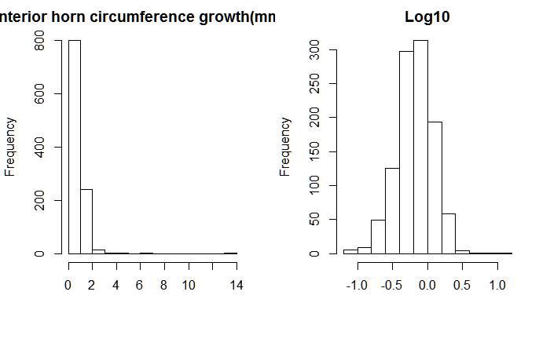

```r
op = par(mfrow=c(1, 2))
hist(df.cv.all.f.c$G_AH_C,
     main = "Anterior horn circumference growth(mm/day)",
     xlab ="")
hist(log10(df.cv.all.f.c$G_AH_C),
     main = "Log10",
     xlab ="")
```

### Model building

```
Call:
glm(formula = G_AH_C ~ 1, family = gaussian(link = "log"), data = df.cv.all.f.c)

Deviance Residuals:
    Min       1Q   Median       3Q      Max
-0.7185  -0.3233  -0.1182   0.2021  12.4941

Coefficients:
            Estimate Std. Error t value Pr(>|t|)
(Intercept) -0.23368    0.02389   -9.78   <2e-16 ***
---
Signif. codes:  0 ‘***’ 0.001 ‘**’ 0.01 ‘*’ 0.05 ‘.’ 0.1 ‘ ’ 1

(Dispersion parameter for gaussian family taken to be 0.3792266)

    Null deviance: 401.6  on 1059  degrees of freedom
Residual deviance: 401.6  on 1059  degrees of freedom
AIC: 1983.4

Number of Fisher Scoring iterations: 6


Call:
glm(formula = G_AH_C ~ N_DEHORNINGS, family = gaussian(link = "log"),
    data = df.cv.all.f.c)

Deviance Residuals:
    Min       1Q   Median       3Q      Max
-0.9903  -0.2164  -0.0506   0.1059  12.1381

Coefficients:
              Estimate Std. Error t value Pr(>|t|)
(Intercept)   -0.72912    0.04476  -16.29   <2e-16 ***
N_DEHORNINGS2  0.86682    0.05147   16.84   <2e-16 ***
N_DEHORNINGS3  0.88599    0.05595   15.83   <2e-16 ***
---
Signif. codes:  0 ‘***’ 0.001 ‘**’ 0.01 ‘*’ 0.05 ‘.’ 0.1 ‘ ’ 1

(Dispersion parameter for gaussian family taken to be 0.2670236)

```

[output cut: 90 more lines]

```

Coefficients:
            Estimate Std. Error t value Pr(>|t|)
(Intercept) -0.32430    0.03837  -8.452  < 2e-16 ***
GENDERM      0.16192    0.04879   3.319 0.000935 ***
---
Signif. codes:  0 ‘***’ 0.001 ‘**’ 0.01 ‘*’ 0.05 ‘.’ 0.1 ‘ ’ 1

(Dispersion parameter for gaussian family taken to be 0.3755656)

    Null deviance: 401.60  on 1059  degrees of freedom
Residual deviance: 397.35  on 1058  degrees of freedom
AIC: 1974.1

Number of Fisher Scoring iterations: 6
```

### Model selection

```
Analysis of Deviance Table

Model 1: G_AH_C ~ 1
Model 2: G_AH_C ~ N_DEHORNINGS
Model 3: G_AH_C ~ CALC_AGE
Model 4: G_AH_C ~ DH_QUARTER
Model 5: G_AH_C ~ B_QUARTER
Model 6: G_AH_C ~ GENDER
  Resid. Df Resid. Dev Df Deviance  Pr(>Chi)
1      1059     401.60
2      1057     282.24  2  119.357 < 2.2e-16 ***
3      1058     399.72 -1 -117.475 < 2.2e-16 ***
4      1056     400.38  2   -0.666
5      1056     401.06  0   -0.680
6      1058     397.35 -2    3.717
---
Signif. codes:  0 ‘***’ 0.001 ‘**’ 0.01 ‘*’ 0.05 ‘.’ 0.1 ‘ ’ 1
Analysis of Deviance Table

Model 1: G_AH_C ~ 1
Model 2: G_AH_C ~ N_DEHORNINGS
  Resid. Df Resid. Dev Df Deviance  Pr(>Chi)
1      1059     401.60
2      1057     282.24  2   119.36 < 2.2e-16 ***
---
Signif. codes:  0 ‘***’ 0.001 ‘**’ 0.01 ‘*’ 0.05 ‘.’ 0.1 ‘ ’ 1
Analysis of Deviance Table

Model 1: G_AH_C ~ 1
Model 2: G_AH_C ~ CALC_AGE
  Resid. Df Resid. Dev Df Deviance Pr(>Chi)
1      1059     401.60
2      1058     399.72  1   1.8821  0.02562 *
---
Signif. codes:  0 ‘***’ 0.001 ‘**’ 0.01 ‘*’ 0.05 ‘.’ 0.1 ‘ ’ 1
Analysis of Deviance Table

Model 1: G_AH_C ~ 1
Model 2: G_AH_C ~ DH_QUARTER
  Resid. Df Resid. Dev Df Deviance Pr(>Chi)
1      1059     401.60
2      1056     400.38  3    1.216   0.3608
Analysis of Deviance Table

Model 1: G_AH_C ~ 1
Model 2: G_AH_C ~ B_QUARTER
  Resid. Df Resid. Dev Df Deviance Pr(>Chi)
1      1059     401.60
2      1056     401.06  3  0.53628   0.7027
Analysis of Deviance Table

Model 1: G_AH_C ~ 1
Model 2: G_AH_C ~ GENDER
  Resid. Df Resid. Dev Df Deviance  Pr(>Chi)
1      1059     401.60
2      1058     397.35  1   4.2532 0.0007648 ***
---
Signif. codes:  0 ‘***’ 0.001 ‘**’ 0.01 ‘*’ 0.05 ‘.’ 0.1 ‘ ’ 1
```

### Final model selection

```
Call:
glm(formula = G_AH_C ~ N_DEHORNINGS + CALC_AGE + GENDER, family = gaussian(link = "log"),
    data = df.cv.all.f.c)

Deviance Residuals:
    Min       1Q   Median       3Q      Max
-0.6879  -0.1597  -0.0535   0.0764  12.0577

Coefficients:
                Estimate Std. Error t value Pr(>|t|)
(Intercept)   -5.799e-01  5.869e-02  -9.881  < 2e-16 ***
N_DEHORNINGS2  9.310e-01  5.251e-02  17.730  < 2e-16 ***
N_DEHORNINGS3  1.032e+00  6.505e-02  15.860  < 2e-16 ***
CALC_AGE      -1.744e-04  3.322e-05  -5.250 1.84e-07 ***
GENDERM        1.475e-01  3.723e-02   3.963 7.90e-05 ***
---
Signif. codes:  0 ‘***’ 0.001 ‘**’ 0.01 ‘*’ 0.05 ‘.’ 0.1 ‘ ’ 1

(Dispersion parameter for gaussian family taken to be 0.2564954)

    Null deviance: 401.6  on 1059  degrees of freedom
Residual deviance: 270.6  on 1055  degrees of freedom
AIC: 1572.8

Number of Fisher Scoring iterations: 7

Analysis of Deviance Table

Model: gaussian, link: log

Response: G_AH_C

Terms added sequentially (first to last)

             Df Deviance Resid. Df Resid. Dev  Pr(>Chi)
NULL                          1059     401.60
N_DEHORNINGS  2  119.357      1057     282.24 < 2.2e-16 ***
CALC_AGE      1    7.477      1056     274.77 6.690e-08 ***
GENDER        1    4.166      1055     270.60 5.578e-05 ***
---
Signif. codes:  0 ‘***’ 0.001 ‘**’ 0.01 ‘*’ 0.05 ‘.’ 0.1 ‘ ’ 1
```

### Interaction

```r
summary(glm8 <- glm(G_AH_C~ N_DEHORNINGS*CALC_AGE + GENDER
                      , df.cv.all.f.c, family = gaussian(link="log")))
```

```
Call:
glm(formula = G_AH_C ~ N_DEHORNINGS * CALC_AGE + GENDER, family = gaussian(link = "log"),
    data = df.cv.all.f.c)

Deviance Residuals:
    Min       1Q   Median       3Q      Max
-0.6649  -0.1317  -0.0121   0.0679  12.0569

Coefficients:
                         Estimate Std. Error t value Pr(>|t|)
(Intercept)             0.0541441  0.1071084   0.506 0.613308
N_DEHORNINGS2           0.1367875  0.1251797   1.093 0.274763
N_DEHORNINGS3           0.1996959  0.1810393   1.103 0.270256
CALC_AGE               -0.0008225  0.0001181  -6.964 5.82e-12 ***
GENDERM                 0.1389965  0.0364645   3.812 0.000146 ***
N_DEHORNINGS2:CALC_AGE  0.0007488  0.0001238   6.046 2.06e-09 ***
N_DEHORNINGS3:CALC_AGE  0.0007407  0.0001346   5.504 4.65e-08 ***
---
Signif. codes:  0 ‘***’ 0.001 ‘**’ 0.01 ‘*’ 0.05 ‘.’ 0.1 ‘ ’ 1

(Dispersion parameter for gaussian family taken to be 0.2472339)

    Null deviance: 401.60  on 1059  degrees of freedom
Residual deviance: 260.34  on 1053  degrees of freedom
AIC: 1535.9

Number of Fisher Scoring iterations: 7
```

```r
anova(glm8, test = "Chisq")
```

```
Analysis of Deviance Table

Model: gaussian, link: log

Response: G_AH_C

Terms added sequentially (first to last)

                      Df Deviance Resid. Df Resid. Dev  Pr(>Chi)
NULL                                   1059     401.60
N_DEHORNINGS           2  119.357      1057     282.24 < 2.2e-16 ***
CALC_AGE               1    7.477      1056     274.77 3.809e-08 ***
GENDER                 1    4.166      1055     270.60 4.047e-05 ***
N_DEHORNINGS:CALC_AGE  2   10.265      1053     260.34 9.636e-10 ***
---
Signif. codes:  0 ‘***’ 0.001 ‘**’ 0.01 ‘*’ 0.05 ‘.’ 0.1 ‘ ’ 1
```

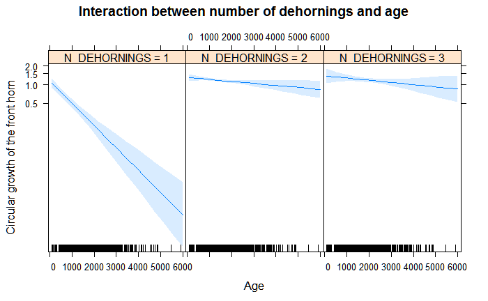

```r
plot(effect("N_DEHORNINGS:CALC_AGE",
            glm8,
            #xlevels=list(CALC_ARRIVAL=900:2000),
            multiline=TRUE),
            main= "Interaction between number of dehornings and age",
            ylab = "Circular growth of the front horn",
            xlab = "Age")
```

### Final model least square means

```
NOTE: Results may be misleading due to involvement in interactions
```

```
$lsmeans
 N_DEHORNINGS  response         SE df asymp.LCL asymp.UCL
 1            0.3118471 0.03024745 NA 0.2578575 0.3771408
 2            1.1559800 0.02895225 NA 1.1006049 1.2141412
 3            1.2155102 0.06486600 NA 1.0947981 1.3495320

Results are averaged over the levels of: GENDER
Confidence level used: 0.95
Intervals are back-transformed from the log scale

$contrasts
 contrast response.ratio         SE df z.ratio p.value
 1 - 2         0.2697686 0.02698305 NA -13.099  <.0001
 1 - 3         0.2565565 0.02838728 NA -12.295  <.0001
 2 - 3         0.9510245 0.05598836 NA  -0.853  0.6700

Results are averaged over the levels of: GENDER
P value adjustment: tukey method for comparing a family of 3 estimates
Tests are performed on the log scale
```

```
NOTE: Results may be misleading due to involvement in interactions
```

```
 CALC_AGE  response         SE df asymp.LCL asymp.UCL
 1567.043 0.7595392 0.02879569 NA 0.7051466 0.8181275

Results are averaged over the levels of: N_DEHORNINGS, GENDER
Confidence level used: 0.95
Intervals are back-transformed from the log scale
 N_DEHORNINGS CALC_AGE  response         SE df asymp.LCL asymp.UCL
 1            1567.043 0.3118471 0.03024745 NA 0.2578575 0.3771408
 2            1567.043 1.1559800 0.02895225 NA 1.1006049 1.2141412
 3            1567.043 1.2155102 0.06486600 NA 1.0947981 1.3495320

Results are averaged over the levels of: GENDER
Confidence level used: 0.95
Intervals are back-transformed from the log scale
$lsmeans
 GENDER  response         SE df asymp.LCL asymp.UCL
 F      0.7085451 0.03074814 NA 0.6507716 0.7714475
 M      0.8142034 0.03313567 NA 0.7517813 0.8818085

Results are averaged over the levels of: N_DEHORNINGS
Confidence level used: 0.95
Intervals are back-transformed from the log scale

$contrasts
 contrast response.ratio         SE df z.ratio p.value
 F - M         0.8702311 0.03173252 NA  -3.812  0.0001

Results are averaged over the levels of: N_DEHORNINGS
Tests are performed on the log scale
```

# Multivariate analysis

### Data preparation

```r
df.cv.mfa <- na.omit(df.cv[,c("GENDER",
                      "N_DEHORNINGS",
                      "G_TOTAL",
                      "G_AH_W",
                      "G_AH_L",
                      "G_AH_C",
                      "CALC_AGE")])
df.cv.mfa$G_TOTAL <- scale(log10(df.cv.mfa$G_TOTAL), center = TRUE, scale = TRUE)
df.cv.mfa$G_AH_W <- scale(log10(df.cv.mfa$G_AH_W), center = TRUE, scale = TRUE)
df.cv.mfa$G_AH_L <- scale(log10(df.cv.mfa$G_AH_L), center = TRUE, scale = TRUE)
df.cv.mfa$G_AH_C <- scale(log10(df.cv.mfa$G_AH_C), center = TRUE, scale = TRUE)
df.cv.mfa$CALC_AGE <- scale(df.cv.mfa$CALC_AGE, center = TRUE, scale = TRUE)
df.cv.mfa[df.cv.mfa$N_DEHORNINGS == "4",]$N_DEHORNINGS <- "3"
df.cv.mfa[df.cv.mfa$N_DEHORNINGS == "5",]$N_DEHORNINGS <- "3"
describe(df.cv.mfa)
```

```
              vars    n mean   sd median trimmed  mad   min  max range  skew
GENDER*          1 1060 1.54 0.50   2.00    1.55 0.00  1.00 2.00  1.00 -0.15
N_DEHORNINGS*    2 1060 1.62 0.75   1.00    1.53 0.00  1.00 3.00  2.00  0.74
G_TOTAL          3 1060 0.00 1.00  -0.12   -0.02 1.18 -3.09 6.49  9.58  0.42
G_AH_W           4 1060 0.00 1.00  -0.08   -0.01 1.18 -3.09 6.81  9.90  0.40
G_AH_L           5 1060 0.00 1.00   0.21    0.14 0.49 -5.03 8.49 13.52 -0.84
G_AH_C           6 1060 0.00 1.00   0.02    0.02 0.91 -3.57 8.20 11.77  0.29
CALC_AGE         7 1060 0.00 1.00  -0.21   -0.13 0.90 -1.77 5.20  6.97  1.33
              kurtosis   se
GENDER*          -1.98 0.02
N_DEHORNINGS*    -0.87 0.02
G_TOTAL           0.91 0.03
G_AH_W            1.34 0.03
G_AH_L            8.71 0.03
G_AH_C            4.79 0.03
CALC_AGE          2.42 0.03
```

### Factor analysis

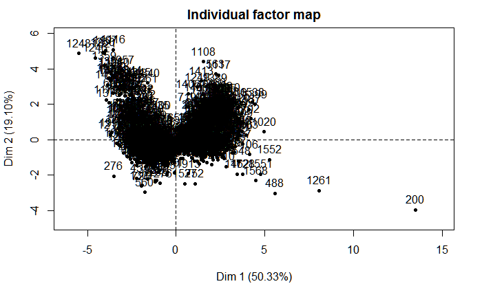

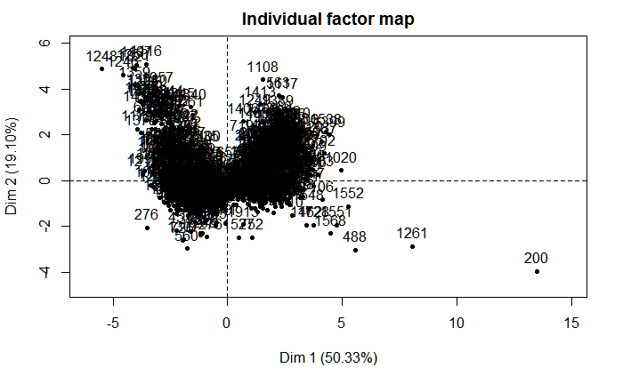

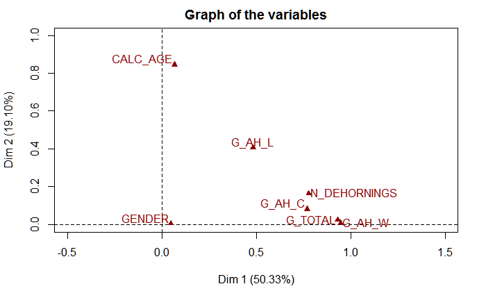

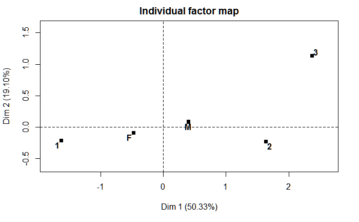

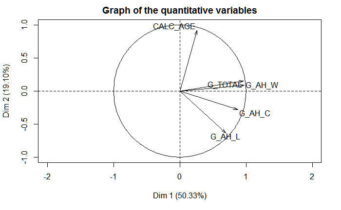

```r
# www.sthda.com/english/articles/31-principal-component-methods-in-r-practical-guide/115-famd-factor-analysis-of-mixed-data-in-r-essentials/
cv.FAMD <- FAMD(df.cv.mfa)
```

Show the eigenvalues and variance and vizualize

```r
eig.val <- get_eigenvalue(cv.FAMD)
head(eig.val)
```

```
      eigenvalue variance.percent cumulative.variance.percent
Dim.1  4.0264811        50.331014                    50.33101
Dim.2  1.5276599        19.095748                    69.42676
Dim.3  1.0291723        12.864654                    82.29142
Dim.4  0.9260278        11.575348                    93.86676
Dim.5  0.2350822         2.938528                    96.80529
```

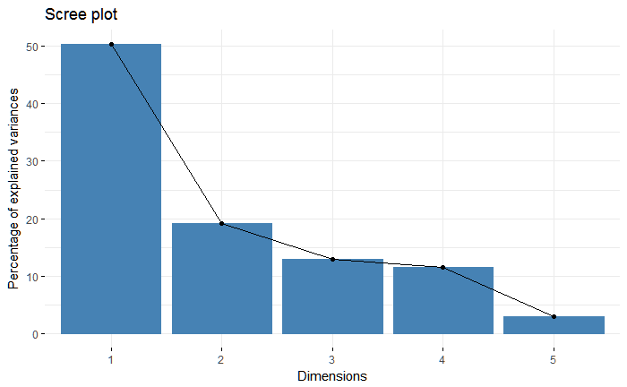

```r
fviz_screeplot(cv.FAMD)
```

Plot the variables and contribution

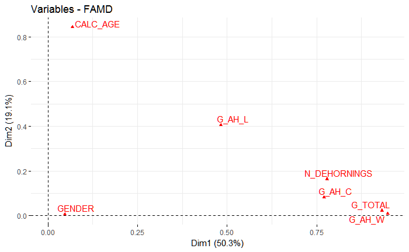

```r
# Define the labels of tick marks
DIM1 <- c("Anterior horn growth",
          "Total growth",
          "Number of dehornings",
          "Anterior horn circumference",
          "Anterior horn length",
          "Age",
          "Sex")
fviz_famd_var(cv.FAMD, repel = TRUE)
```

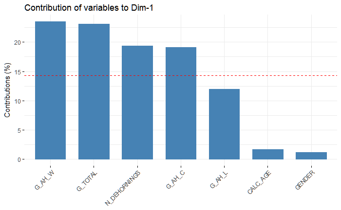

```r
# Contribution to the first dimension
fviz_contrib(cv.FAMD, "var",
             axes = 1,
             x.lab = DIM1)
```

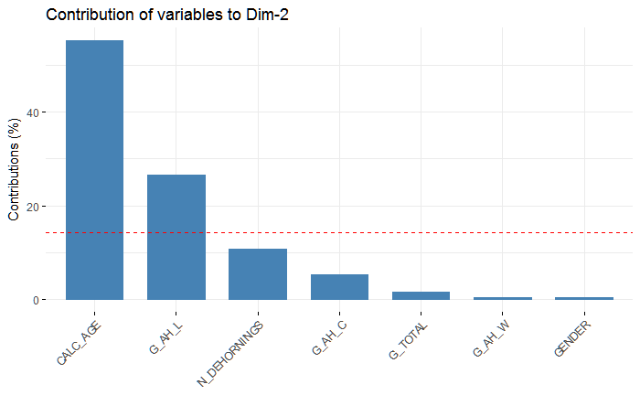

```r
# Contribution to the second dimension
fviz_contrib(cv.FAMD, "var",
             axes = 2)
```

Focus on the quantitative variables

```r
quanti.var <- get_famd_var(cv.FAMD, "quanti.var")
quanti.var
```

```
FAMD results for quantitative variables
 ===================================================
  Name       Description
1 "$coord"   "Coordinates"
2 "$cos2"    "Cos2, quality of representation"
3 "$contrib" "Contributions"
```

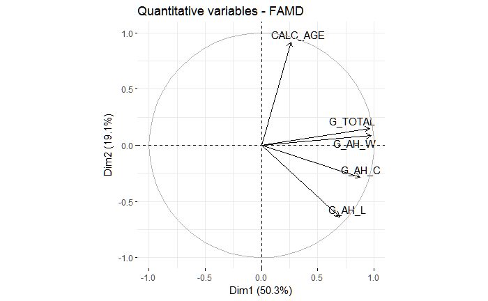

```r
fviz_famd_var(cv.FAMD, "quanti.var", repel = TRUE,
              col.var = "black")
```

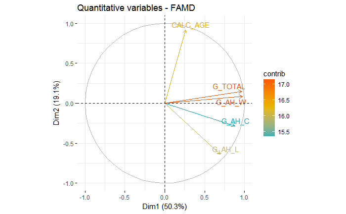

```r
fviz_famd_var(cv.FAMD, "quanti.var", col.var = "contrib",
             gradient.cols = c("#00AFBB", "#E7B800", "#FC4E07"),
             repel = TRUE)
```

Focus on the qualitative variables

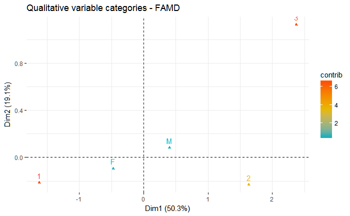

```r
fviz_famd_var(cv.FAMD, "quali.var", col.var = "contrib",
             gradient.cols = c("#00AFBB", "#E7B800", "#FC4E07")
             )
```

Plot the individual observations

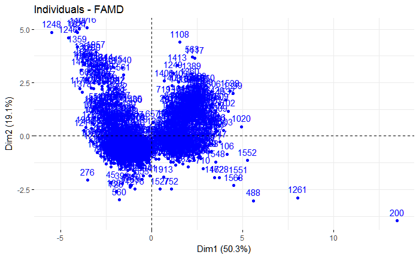

```r
fviz_mfa_ind(cv.FAMD,
             #habillage = "Label", # color by groups
             palette = c("#00AFBB", "#E7B800", "#FC4E07"),
             addEllipses = TRUE,
             ellipse.type = "confidence",
             repel = FALSE # Avoid text overlapping
             )
```

```r
flabels <- c("Number of dehornings", "Sex")
fviz_ellipses(cv.FAMD, c("N_DEHORNINGS", "GENDER"),
              addEllipses = TRUE,
              ellipse.type = "confidence",
              geom = "point",
              main = "Qualitative variables"
              )
```

[output not shown]